# Pilot data fMRI - 15. 09.

Gianluca Macauda

15 9 2019

## Load the data for both tasks

Read all data files from the task folder and clean the data

## Accuracy Plots

First, we plot the accuracy for each participant and condition. We also divide between the van gaal version (easy) and the staircase version (difficult)

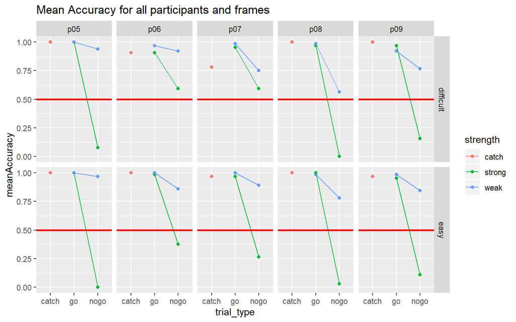

## Response Times

Next, we have a look at the response times. First for the van Gaal version.

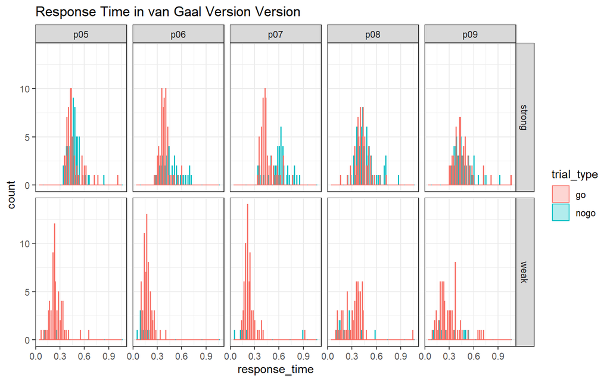

And for the Staircase Version:

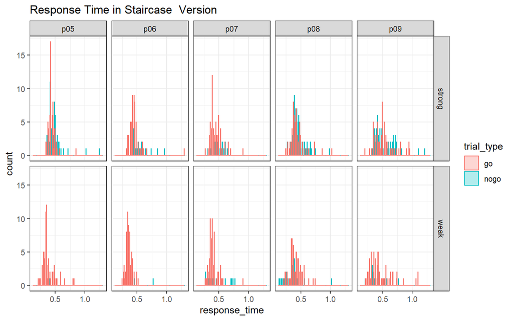

## shifted lognormal for response times in strongly masked conditions

Next, we try to fit shifted lognormal for the response times in the strongly masked condition. The staircase and van Gaal version are mixed together. Participants are modeled as random effect. The shift (non decision time) is influenced by the participants, so that different participants can have different shifts of the lognormal distribution. However, it shows a slightly slower response time for the nogo trials in the strongly masked condition. This is what van Gaal found!

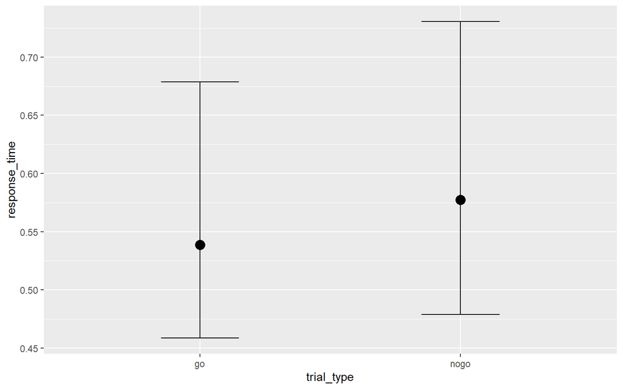

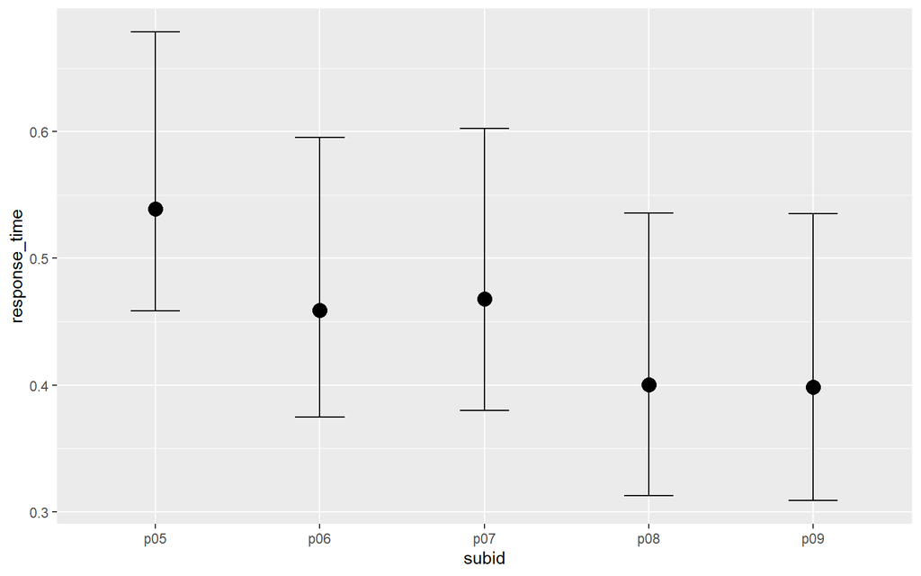

```
##  Family: shifted_lognormal
##   Links: mu = identity; sigma = identity; ndt = log
## Formula: response_time ~ trial_type + (trial_type | subid)
##          ndt ~ subid
##    Data: rtDataStrongMask (Number of observations: 1120)
## Samples: 4 chains, each with iter = 2000; warmup = 1000; thin = 1;
##          total post-warmup samples = 4000
##
## Group-Level Effects:
## ~subid (Number of levels: 5)
##                               Estimate Est.Error l-95% CI u-95% CI Rhat
## sd(Intercept)                     0.40      0.23     0.15     1.02 1.00
## sd(trial_typenogo)                0.14      0.11     0.03     0.40 1.00
## cor(Intercept,trial_typenogo)    -0.13      0.45    -0.88     0.76 1.00
##                               Bulk_ESS Tail_ESS
## sd(Intercept)                     1101     1628
## sd(trial_typenogo)                1060     1349
## cor(Intercept,trial_typenogo)     2306     2246
##
## Population-Level Effects:
##                Estimate Est.Error l-95% CI u-95% CI Rhat Bulk_ESS Tail_ESS
## Intercept         -1.27      0.18    -1.62    -0.90 1.00     1284     1817
## ndt_Intercept     -1.41      0.06    -1.54    -1.32 1.00     2258     1889
## trial_typenogo     0.12      0.08    -0.04     0.26 1.00     1742     1513
## ndt_subidp06      -0.41      0.09    -0.61    -0.25 1.00     2862     2647
## ndt_subidp07      -0.36      0.10    -0.59    -0.19 1.00     2474     1666
## ndt_subidp08      -0.87      0.15    -1.18    -0.66 1.00     2393     1413
## ndt_subidp09      -0.92      0.31    -1.51    -0.59 1.00     1726     1268
##
## Family Specific Parameters:
##       Estimate Est.Error l-95% CI u-95% CI Rhat Bulk_ESS Tail_ESS
## sigma     0.35      0.02     0.31     0.38 1.00     1543     1382
##
## Samples were drawn using sampling(NUTS). For each parameter, Eff.Sample
## is a crude measure of effective sample size, and Rhat is the potential
## scale reduction factor on split chains (at convergence, Rhat = 1).
```

## D-Prime

Some signal detection models.

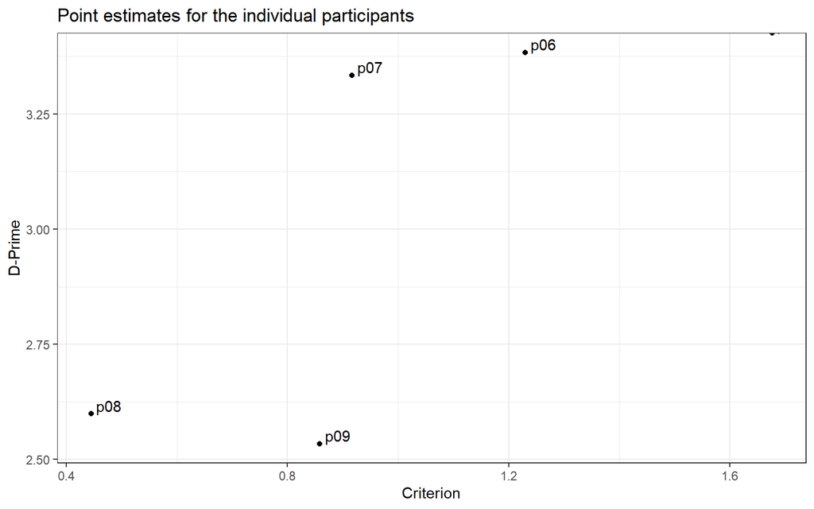

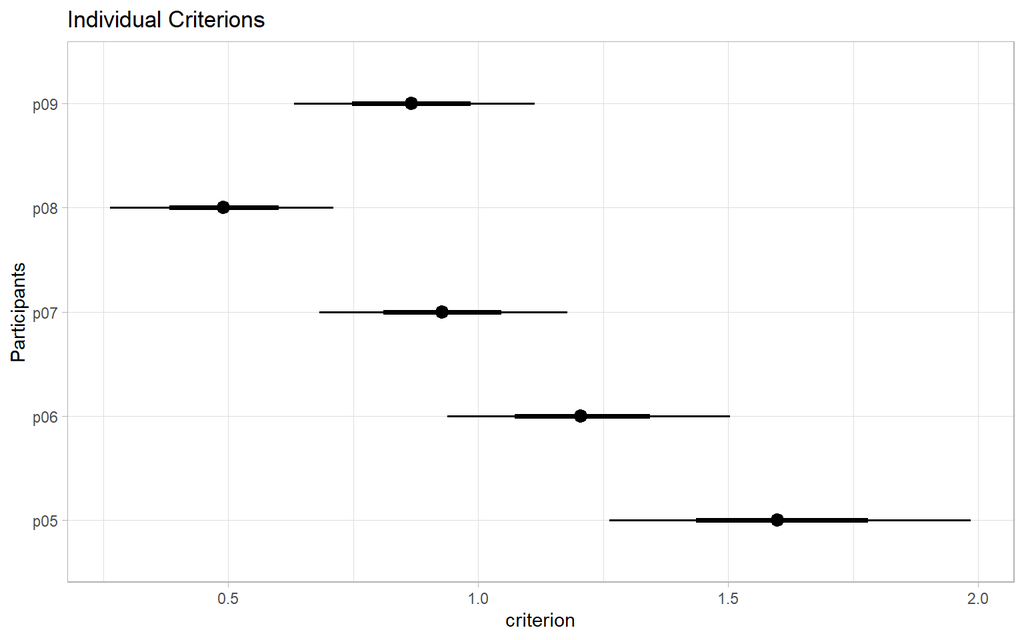

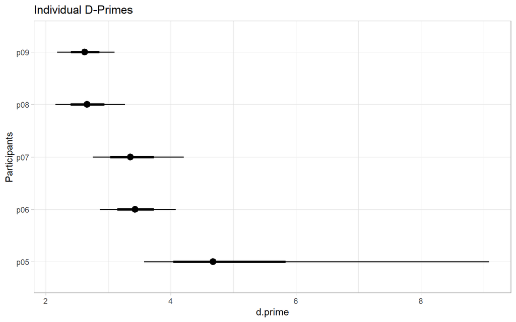

Last, a summary of Point estimates of the criterion and d-prime and the posterior density from the hierarchical model.

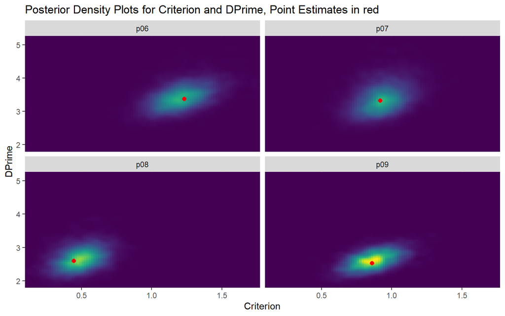